# Pertemuan-2

## Library/Packages

*Package* R yang akan digunakan pada perkuliahan Analisis Deret Waktu sesi UTS adalah: `forecast`, `graphics`, `TTR`, `TSA` . Jika *package* tersebut belum ada, silakan install terlebih dahulu.

```r
#install.packages("forecast")
#install.packages("graphics")
#install.packages("TTR")
#install.packages("TSA")
```

Jika sudah ada, silakan panggil library *package* tersebut.

```r
library("forecast")
```

```r
library("graphics")
library("TTR")
library("TSA")
```

## Impor Data

```r
library(rio) #install packages jika belum ada
library(readxl)
#data1 <- import("https://raw.githubusercontent.com/windipngsti/Praktikum-STA1341/refs/heads/main/Pertemuan%202/Data_1.csv")
#data2 <- import("https://raw.githubusercontent.com/windipngsti/Praktikum-STA1341/refs/heads/main/Pertemuan%202/Data_2.csv")

#via csv gunakan read.csv("namafile.csv")
data1 <- read_excel("D:\\KULIAH\\Semester 5\\DATA SEMESTER 5\\Air Quality Index.xlsx")

# menampilkan 5 data pertama
head(data1)
```

```
## # A tibble: 6 × 3
##       t Tanggal    `PM2.5(ug/m3)`
##   <dbl> <chr>               <dbl>
## 1     1 2024-01-01           69.3
## 2     2 2024-01-02           56.4
## 3     3 2024-01-03           40.1
## 4     4 2024-01-04           49.7
## 5     5 2024-01-05           49.3
## 6     6 2024-01-06           59.8
```

## Eksplorasi Data

`View()` : menampilkan data dalam bentuk tabel, `str()` : menampilkan struktur data, `dim()` : menampilkan dimensi data

```r
View(data1)
str(data1)
```

```
## tibble [156 × 3] (S3: tbl_df/tbl/data.frame)
##  $ t           : num [1:156] 1 2 3 4 5 6 7 8 9 10 ...
##  $ Tanggal     : chr [1:156] "2024-01-01" "2024-01-02" "2024-01-03" "2024-01-04" ...
##  $ PM2.5(ug/m3): num [1:156] 69.3 56.4 40.1 49.7 49.3 ...
```

```r
dim(data1)
```

```
## [1] 156   3
```

Mengubah data agar terbaca sebagai data deret waktu dengan fungsi `ts()` .

```r
data1.ts <- ts(data1$"PM2.5(ug/m3)")
```

Menampilkan ringkasan data

```r
summary(data1.ts)
```

```
##    Min. 1st Qu.  Median    Mean 3rd Qu.    Max.
##   12.41   36.50   58.49   56.78   73.01  116.88
```

Membuat plot data deret waktu

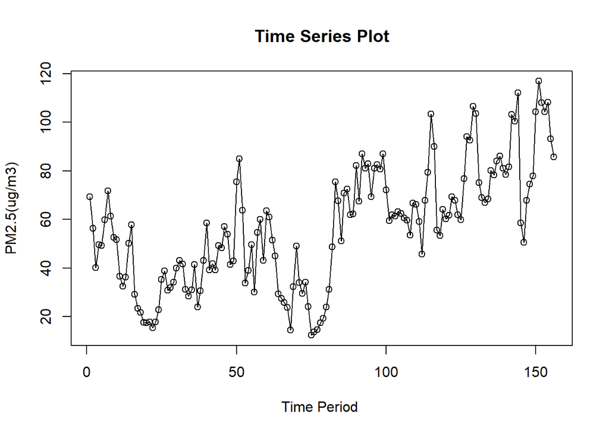

```r
ts.plot(data1.ts, xlab="Time Period ", ylab="PM2.5(ug/m3)",
        main = "Time Series Plot")
points(data1.ts)
```

```r
#menyimpan plot
dev.copy(png, "plot_data1.png")
```

```r
dev.off()
```

## Single Moving Average & Double Moving Average

### Pembagian Data

Pembagian data latih dan data uji dilakukan dengan perbandingan 80% data latih dan 20% data uji.

```r
# hitung jumlah data
n <- nrow(data1)

# tentukan batas 80%
n_train <- floor(0.8 * n)

# bagi data
training_ma <- data1[1:n_train, ]
testing_ma  <- data1[(n_train+1):n, ]

# ubah ke time series
train_ma.ts <- ts(training_ma$"PM2.5(ug/m3)")
test_ma.ts  <- ts(testing_ma$"PM2.5(ug/m3)")
```

Eksplorasi data dilakukan pada keseluruhan data, data latih serta data uji menggunakan plot data deret waktu.

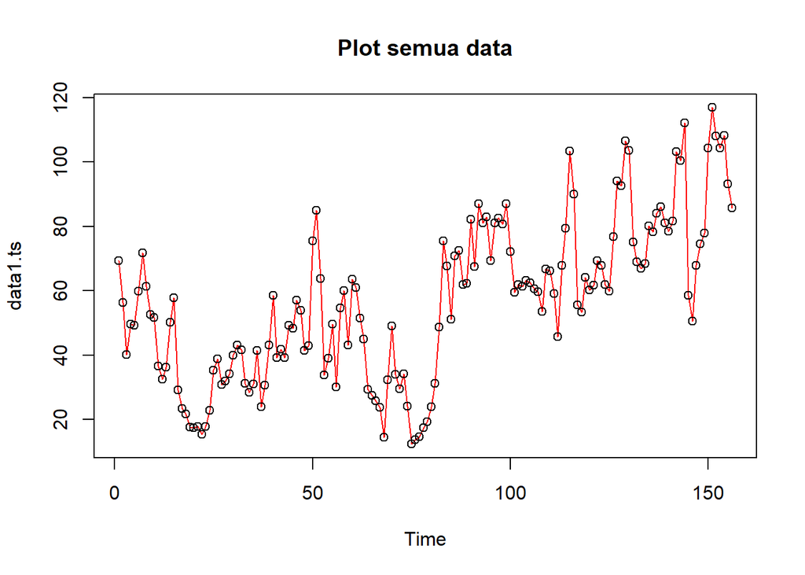

```r
#eksplorasi keseluruhan data
plot(data1.ts, col="red",main="Plot semua data")
points(data1.ts)
```

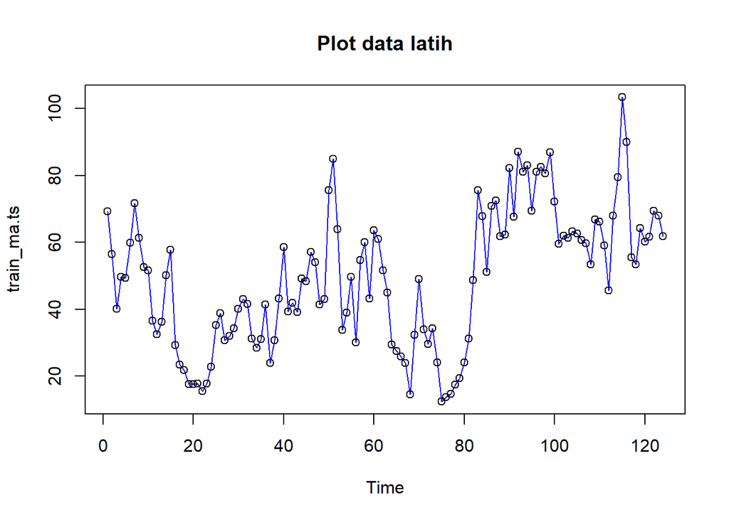

```r
#eksplorasi data latih
plot(train_ma.ts, col="blue",main="Plot data latih")
points(train_ma.ts)
```

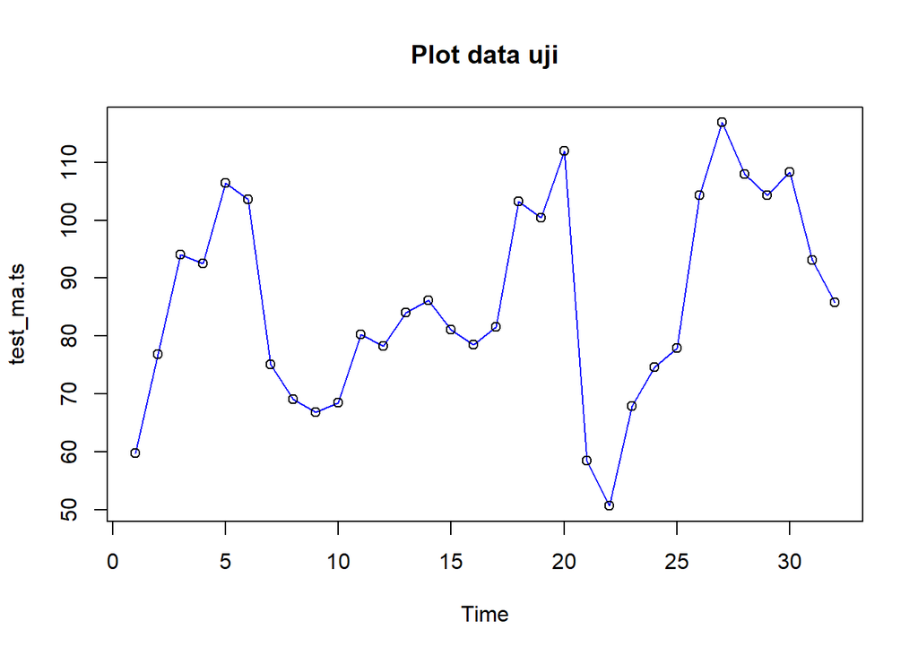

```r
#eksplorasi data uji
plot(test_ma.ts, col="blue",main="Plot data uji")
points(test_ma.ts)
```

Eksplorasi data juga dapat dilakukan menggunakan package `ggplot2` dengan terlebih dahulu memanggil library *package* `ggplot2`.

[figure not shown]

```r
library(ggplot2)
ggplot() +
  geom_line(data = training_ma, aes(x = t, y = "PM2.5(ug/m3)", col = "Data Latih")) +
  geom_line(data = testing_ma, aes(x = t, y = "PM2.5(ug/m3)", col = "Data Uji")) +
  labs(x = "Periode Waktu", y = "PM2.5(ug/m3)", color = "Legend") +
   scale_colour_manual(name="Keterangan:", breaks = c("Data Latih", "Data Uji"),
                      values = c("blue", "red")) +
  theme_bw() + theme(legend.position = "bottom",
                     plot.caption = element_text(hjust=0.5, size=12))
```

### Single Moving Average (SMA)

Ide dasar dari Single Moving Average (SMA) adalah data suatu periode dipengaruhi oleh data periode sebelumnya. Metode pemulusan ini cocok digunakan untuk pola data stasioner atau konstan. Prinsip dasar metode pemulusan ini adalah data pemulusan pada periode ke-t merupakan rata rata dari m buah data pada periode ke-t hingga periode ke (t-m+1).

$$S_t = \frac{1}{m} \sum_{i=t-m+1}^{t} X_i$$

Data pemulusan pada periode ke-t selanjutnya digunakan sebagai nilai peramalan pada periode ke t+1.

$$F_t = S_{t-1}, F_{n,h} = S_n$$

Pemulusan menggunakan metode SMA dilakukan dengan fungsi `SMA()`. Dalam hal ini akan dilakukan pemulusan dengan parameter `m=4`.

```r
data.sma<-SMA(train_ma.ts, n=4)
data.sma
```

```
## Time Series:
## Start = 1
## End = 124
## Frequency = 1
##   [1]       NA       NA       NA 53.85417 48.85105 49.70312 57.60728 60.52603
##   [9] 61.35103 59.29270 50.51875 43.29480 39.21460 38.86668 44.17188 43.37915
##  [17] 40.18020 33.06875 23.03855 20.10940 18.69792 17.13020 17.16977 18.48642
##  [25] 22.86352 28.71457 31.95417 34.25940 33.98960 34.27710 37.33855 39.71875
##  [33] 38.94792 36.03960 33.05315 33.01670 31.22502 31.80835 34.83230 39.10417
##  [41] 42.92812 45.70625 44.70000 42.37812 44.65625 48.45730 52.16042 50.21457
##  [49] 48.86562 53.47707 61.23540 66.83332 64.54895 55.43540 46.60102 38.17915
##  [57] 43.40102 48.64270 47.02292 55.39897 56.94585 54.82397 55.28335 46.73335
##  [65] 38.36147 31.92917 26.63645 22.91457 24.12915 29.93852 32.47915 36.24685
##  [73] 36.72707 30.48645 25.08020 21.11665 16.22290 14.55520 16.29167 18.85417
##  [81] 23.00730 30.84062 44.89270 55.82395 60.80102 66.32290 65.55310 64.08122
##  [89] 66.87705 69.72497 68.49685 74.79582 79.46457 79.64375 80.08855 78.57292
##  [97] 78.95940 78.38335 82.78127 80.58752 74.81667 70.14687 63.75832 61.50310
## [105] 62.26560 61.93332 61.50102 59.06770 60.11875 61.50102 61.34477 59.39060
## [113] 59.68122 63.00415 74.07707 85.16562 82.06457 75.56665 65.79372 58.33642
## [121] 59.89165 63.88227 64.80415 65.21875
```

Data pemulusan pada periode ke-t selanjutnya digunakan sebagai nilai peramalan pada periode ke t+1 sehingga hasil peramalan 1 periode kedepan adalah sebagai berikut.

```r
data.ramal<-c(NA,data.sma)
data.ramal #forecast 1 periode ke depan
```

```
##   [1]       NA       NA       NA       NA 53.85417 48.85105 49.70312 57.60728
##   [9] 60.52603 61.35103 59.29270 50.51875 43.29480 39.21460 38.86668 44.17188
##  [17] 43.37915 40.18020 33.06875 23.03855 20.10940 18.69792 17.13020 17.16977
##  [25] 18.48642 22.86352 28.71457 31.95417 34.25940 33.98960 34.27710 37.33855
##  [33] 39.71875 38.94792 36.03960 33.05315 33.01670 31.22502 31.80835 34.83230
##  [41] 39.10417 42.92812 45.70625 44.70000 42.37812 44.65625 48.45730 52.16042
##  [49] 50.21457 48.86562 53.47707 61.23540 66.83332 64.54895 55.43540 46.60102
##  [57] 38.17915 43.40102 48.64270 47.02292 55.39897 56.94585 54.82397 55.28335
##  [65] 46.73335 38.36147 31.92917 26.63645 22.91457 24.12915 29.93852 32.47915
##  [73] 36.24685 36.72707 30.48645 25.08020 21.11665 16.22290 14.55520 16.29167
##  [81] 18.85417 23.00730 30.84062 44.89270 55.82395 60.80102 66.32290 65.55310
##  [89] 64.08122 66.87705 69.72497 68.49685 74.79582 79.46457 79.64375 80.08855
##  [97] 78.57292 78.95940 78.38335 82.78127 80.58752 74.81667 70.14687 63.75832
## [105] 61.50310 62.26560 61.93332 61.50102 59.06770 60.11875 61.50102 61.34477
## [113] 59.39060 59.68122 63.00415 74.07707 85.16562 82.06457 75.56665 65.79372
## [121] 58.33642 59.89165 63.88227 64.80415 65.21875
```

```r
data.gab<-cbind(
  aktual=c(data1.ts),
  pemulusan=c(data.sma,rep(NA,24)),
  ramalan=c(data.ramal,rep(data.ramal[length(data.ramal)],23)))
data.gab #forecast 24 periode ke depan
```

```
##          aktual pemulusan  ramalan
##   [1,]  69.2708        NA       NA
##   [2,]  56.4167        NA       NA
##   [3,]  40.0667        NA       NA
##   [4,]  49.6625  53.85417       NA
##   [5,]  49.2583  48.85105 53.85417
##   [6,]  59.8250  49.70312 48.85105
##   [7,]  71.6833  57.60728 49.70312
##   [8,]  61.3375  60.52603 57.60728
##   [9,]  52.5583  61.35103 60.52603
##  [10,]  51.5917  59.29270 61.35103
##  [11,]  36.5875  50.51875 59.29270
##  [12,]  32.4417  43.29480 50.51875
##  [13,]  36.2375  39.21460 43.29480
##  [14,]  50.2000  38.86668 39.21460
```

[output cut: 142 more lines]

Adapun plot data deret waktu dari hasil peramalan yang dilakukan adalah sebagai berikut.

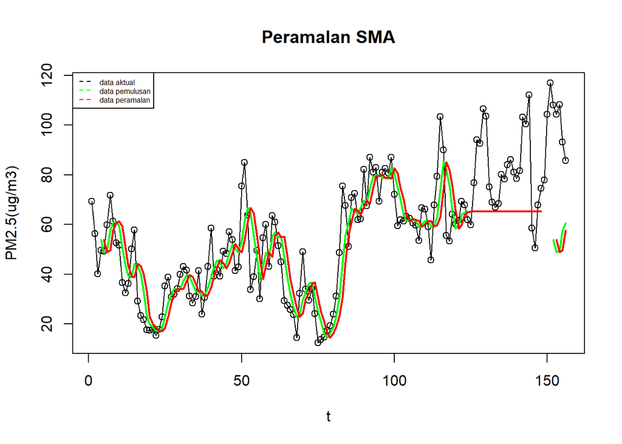

```r
ts.plot(data1.ts, xlab="t", ylab="PM2.5(ug/m3)", main= "Peramalan SMA")
points(data1.ts)
lines(data.gab[,2],col="green",lwd=2)
lines(data.gab[,3],col="red",lwd=2)
legend("topleft",c("data aktual","data pemulusan","data peramalan"), lty=8, col=c("black","green","red"), cex=0.5)
```

Selanjutnya perhitungan akurasi dilakukan dengan ukuran akurasi *Sum Squares Error* (SSE), *Mean Square Error* (MSE) dan *Mean Absolute Percentage Error* (MAPE). Perhitungan akurasi dilakukan baik pada data latih maupun pada data uji.

$$SSE = \sum_{t=1}^{n} (y_t - \hat{y}_t)^2$$

$$MSE = \frac{1}{n} \sum_{t=1}^{n} (y_t - \hat{y}_t)^2$$
$$MAPE = \frac{1}{n} \sum_{t=1}^{n} \left|\frac{y_t -
\hat{y}_t}{y_t}\right| * 100$$

```r
#Menghitung nilai keakuratan data latih
error_train.sma = train_ma.ts-data.ramal[1:length(train_ma.ts)]

SSE_train.sma = sum(error_train.sma[5:length(train_ma.ts)]^2)
MSE_train.sma = mean(error_train.sma[5:length(train_ma.ts)]^2)
MAPE_train.sma = mean(abs((error_train.sma[5:length(train_ma.ts)]/train_ma.ts[5:length(train_ma.ts)])*100))

akurasi_train.sma <- matrix(c(SSE_train.sma, MSE_train.sma, MAPE_train.sma))
row.names(akurasi_train.sma)<- c("SSE", "MSE", "MAPE")
colnames(akurasi_train.sma) <- c("Akurasi m = 4")
akurasi_train.sma
```

```
##      Akurasi m = 4
## SSE    23171.28378
## MSE      193.09403
## MAPE      26.32565
```

Dalam hal ini nilai MAPE data latih pada metode pemulusan SMA sekitar 26,3%, nilai ini dapat dikategorikan sebagai nilai akurasi yang buruk. Selanjutnya dilakukan perhitungan nilai MAPE data uji pada metode pemulusan SMA.

```r
#Menghitung nilai keakuratan data uji
error_test.sma = test_ma.ts-data.gab[97:120,3]
```

```r
SSE_test.sma = sum(error_test.sma^2)
MSE_test.sma = mean(error_test.sma^2)
MAPE_test.sma = mean(abs((error_test.sma/test_ma.ts*100)))

akurasi_test.sma <- matrix(c(SSE_test.sma, MSE_test.sma, MAPE_test.sma))
row.names(akurasi_test.sma)<- c("SSE", "MSE", "MAPE")
colnames(akurasi_test.sma) <- c("Akurasi m = 4")
akurasi_test.sma
```

```
##      Akurasi m = 4
## SSE    17424.24937
## MSE      544.50779
## MAPE      23.48458
```

### Double Moving Average (DMA)

Metode pemulusan Double Moving Average (DMA) pada dasarnya mirip dengan SMA. Namun demikian, metode ini lebih cocok digunakan untuk pola data trend. Proses pemulusan dengan rata rata dalam metode ini dilakukan sebanyak 2 kali.

- **Tahap I:**

$$S_{1,t} = \frac{1}{m} \sum_{i=t-m+1}^{t} X_i$$

- **Tahap II:**

$$S_{2,t} = \frac{1}{m} \sum_{i=t-m+1}^{t} S_{1,i}$$

Forecast $h$ langkah ke depan dihitung dengan:

$$F_{2,t,t+h} = A_t + B_t \,(h)$$

dengan komponen level ($A_t$) dan tren ($B_t$):

$$A_t = 2S_{1,t} - S_{2,t}
\qquad\text{dan}\qquad
B_t = \frac{2}{m-1}\,\big(S_{1,t} - S_{2,t}\big)$$

```r
dma <- SMA(data.sma, n = 4)
At <- 2*data.sma - dma
Bt <- 2/(4-1)*(data.sma - dma)
data.dma<- At+Bt
data.ramal2<- c(NA, data.dma)

t = 1:24
f = c()

for (i in t) {
  f[i] = At[length(At)] + Bt[length(Bt)]*(i)
}

data.gab2 <- cbind(aktual = c(data1.ts),
                   pemulusan1 = c(data.sma,rep(NA,24)),
                   pemulusan2 = c(dma, rep(NA,24)),
                   At = c(At, rep(NA,24)),
                   Bt = c(Bt,rep(NA,24)),
                   ramalan = c(data.ramal2, f[-1]))
data.gab2
```

```
##          aktual pemulusan1 pemulusan2        At         Bt    ramalan
##   [1,]  69.2708         NA         NA        NA         NA         NA
##   [2,]  56.4167         NA         NA        NA         NA         NA
##   [3,]  40.0667         NA         NA        NA         NA         NA
##   [4,]  49.6625   53.85417         NA        NA         NA         NA
##   [5,]  49.2583   48.85105         NA        NA         NA         NA
##   [6,]  59.8250   49.70312         NA        NA         NA         NA
##   [7,]  71.6833   57.60728   52.50391 62.710644  3.4022458         NA
##   [8,]  61.3375   60.52603   54.17187 66.880181  4.2361042  66.112890
##   [9,]  52.5583   61.35103   57.29686 65.405188  2.7027750  71.116285
##  [10,]  51.5917   59.29270   59.69426 58.891144 -0.2677042  68.107963
##  [11,]  36.5875   50.51875   57.92213 43.115375 -4.9355833  58.623440
##  [12,]  32.4417   43.29480   53.61432 32.975281 -6.8796792  38.179792
##  [13,]  36.2375   39.21460   48.08021 30.348987 -5.9104083  26.095602
##  [14,]  50.2000   38.86668   42.97371 34.759644 -2.7380208  24.438579
```

[output cut: 142 more lines]

Hasil pemulusan menggunakan metode DMA divisualisasikan sebagai berikut

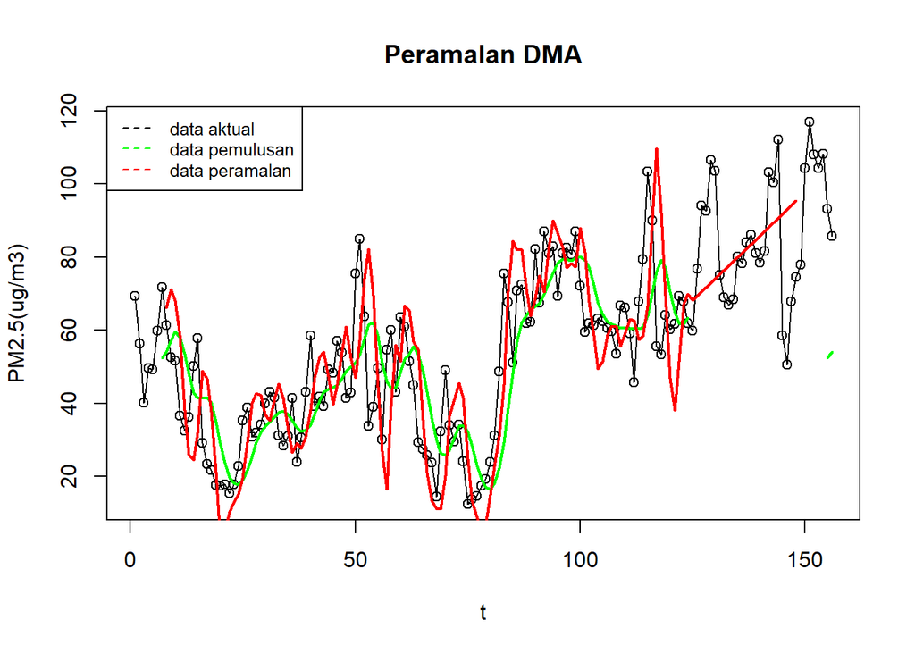

```r
ts.plot(data1.ts, xlab="t", ylab="PM2.5(ug/m3)", main= "Peramalan DMA")
points(data1.ts)
lines(data.gab2[,3],col="green",lwd=2)
lines(data.gab2[,6],col="red",lwd=2)
legend("topleft",c("data aktual","data pemulusan","data peramalan"), lty=8, col=c("black","green","red"), cex=0.8)
```

Selanjutnya perhitungan akurasi dilakukan baik pada data latih maupun data uji. Perhitungan akurasi dilakukan dengan ukuran akurasi SSE, MSE dan MAPE.

```r
#Menghitung nilai keakuratan data latih
error_train.dma = train_ma.ts-data.ramal2[1:length(train_ma.ts)]

SSE_train.dma = sum(error_train.dma[8:length(train_ma.ts)]^2)
MSE_train.dma = mean(error_train.dma[8:length(train_ma.ts)]^2)
MAPE_train.dma = mean(abs((error_train.dma[8:length(train_ma.ts)]/train_ma.ts[8:length(train_ma.ts)])*100))

akurasi_train.dma <- matrix(c(SSE_train.dma, MSE_train.dma, MAPE_train.dma))
row.names(akurasi_train.dma)<- c("SSE", "MSE", "MAPE")
colnames(akurasi_train.dma) <- c("Akurasi m = 4")
akurasi_train.dma
```

```
##      Akurasi m = 4
## SSE    30835.16735
## MSE      263.54844
## MAPE      30.85084
```

Perhitungan akurasi pada data latih menggunakan nilai MAPE menghasilkan nilai MAPE 30% sehingga dikategorikan buruk. Selanjutnya, perhitungan nilai akurasi dilakukan pada data uji.

```r
#Menghitung nilai keakuratan data uji
error_test.dma = test_ma.ts-data.gab2[97:120,6]
```

```r
SSE_test.dma = sum(error_test.dma^2)
MSE_test.dma = mean(error_test.dma^2)
MAPE_test.dma = mean(abs((error_test.dma/test_ma.ts*100)))

akurasi_test.dma <- matrix(c(SSE_test.dma, MSE_test.dma, MAPE_test.dma))
row.names(akurasi_test.dma)<- c("SSE", "MSE", "MAPE")
colnames(akurasi_test.dma) <- c("Akurasi m = 4")
akurasi_test.dma
```

```
##      Akurasi m = 4
## SSE     22911.6579
## MSE       715.9893
## MAPE       28.2679
```

## Single Exponential Smoothing & Double Exponential Smoothing

Metode Exponential Smoothing merupakan metode pemulusan deret waktu dengan memberikan bobot yang menurun secara eksponensial pada data historis, di mana nilai terbaru mendapat bobot lebih besar dibanding nilai yang lebih lama. Metode ini menggunakan satu atau lebih parameter pemulusan yang secara langsung menentukan besar kecilnya bobot setiap pengamatan. Pemilihan parameter yang tepat akan sangat berpengaruh terhadap hasil ramalan. Secara umum, Exponential Smoothing dibedakan menjadi dua jenis, yaitu model tunggal (single) yang digunakan untuk data tanpa tren maupun musiman, serta model ganda (double) yang mampu menangkap adanya tren pada data.

### Pembagian Data

Pembagian data latih dan data uji dilakukan dengan perbandingan 80% data latih dan 20% data uji.

```r
# jumlah baris data
n <- nrow(data1)

# hitung batas 80%
n_train <- floor(0.8 * n)

# bagi data
training <- data1[1:n_train, ]
testing  <- data1[(n_train+1):n, ]

# ubah ke time series
train.ts <- ts(training$"PM2.5(ug/m3)")
test.ts  <- ts(testing$"PM2.5(ug/m3)")
```

### Eksplorasi

Eksplorasi dilakukan dengan membuat plot data deret waktu untuk keseluruhan data, data latih, dan data uji.

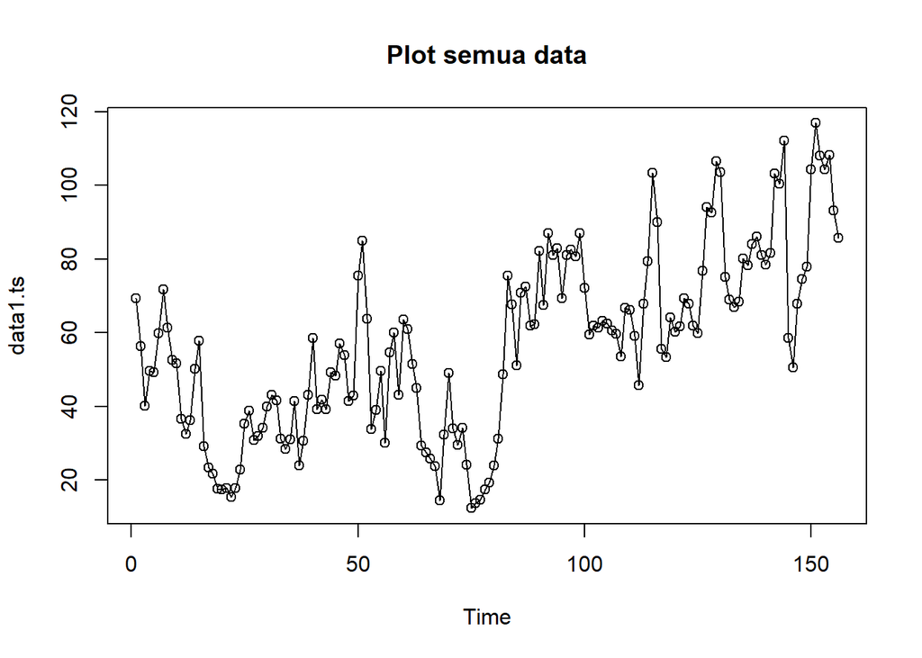

```r
#eksplorasi data
plot(data1.ts, col="black",main="Plot semua data")
points(data1.ts)
```

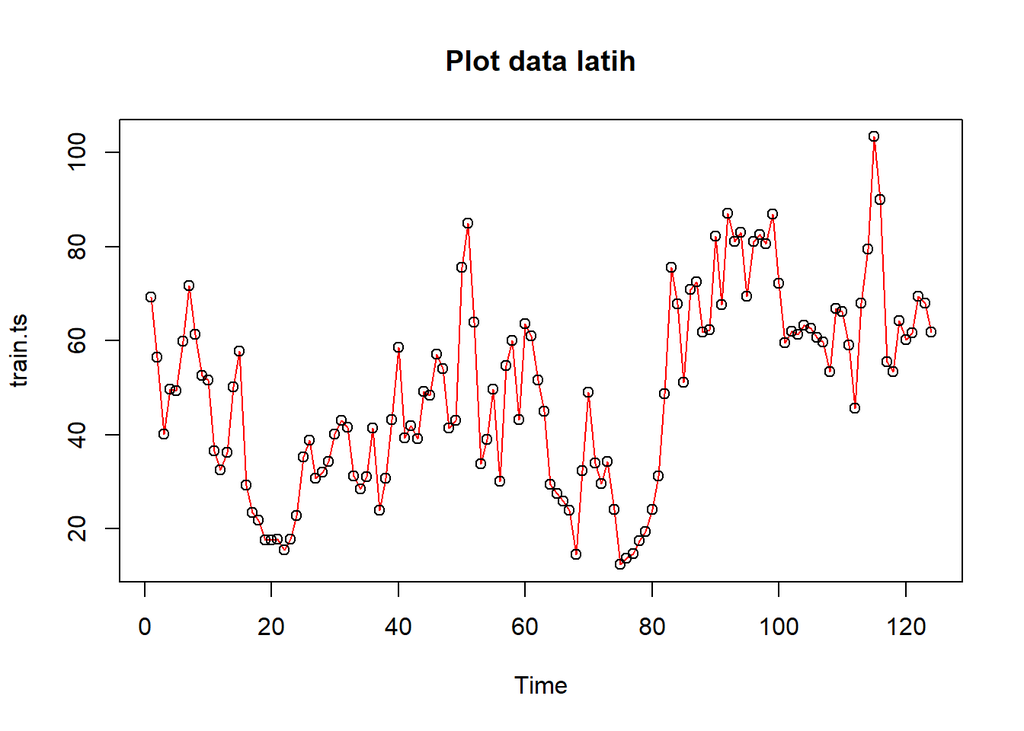

```r
plot(train.ts, col="red",main="Plot data latih")
points(train.ts)
```

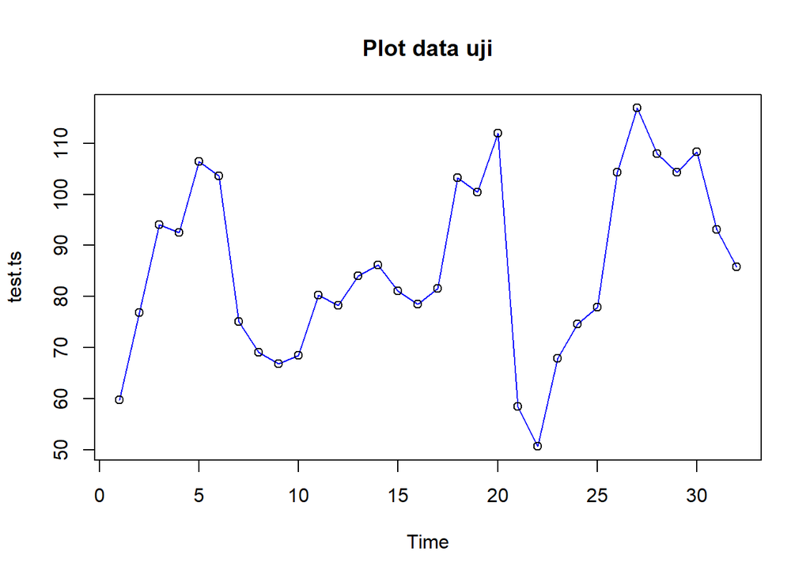

```r
plot(test.ts, col="blue",main="Plot data uji")
points(test.ts)
```

[figure not shown]

```r
#Eksplorasi dengan GGPLOT
library(ggplot2)
ggplot() +
  geom_line(data = training, aes(x = t, y = "PM2.5(ug/m3)", col = "Data Latih")) +
  geom_line(data = testing, aes(x = t, y = "PM2.5(ug/m3)", col = "Data Uji")) +
  labs(x = "Periode Waktu", y = "Membaca", color = "Legend") +
  scale_colour_manual(name="Keterangan:", breaks = c("Data Latih", "Data Uji"),
                      values = c("blue", "red")) +
  theme_bw() + theme(legend.position = "bottom",
                     plot.caption = element_text(hjust=0.5, size=12))
```

## Single Exponential Smoothing

Single Exponential Smoothing (SES) adalah metode peramalan deret waktu yang dikembangkan untuk mengatasi kelemahan Moving Average. Jika pada Moving Average setiap data periode sebelumnya dianggap memiliki bobot yang sama, maka SES memberikan bobot yang semakin mengecil secara eksponensial terhadap data lama, sehingga data terbaru diberi bobot lebih besar.

Single Exponential Smoothing merupakan metode pemulusan yang tepat digunakan untuk data dengan pola stasioner atau konstan.

Nilai pemulusan pada periode ke-t didapat dari persamaan:

$$\tilde{y}_T=\lambda
y_t+(1-\lambda)\tilde{y}_{T-1}$$

Nilai parameter $\lambda$ adalah nilai antara 0 dan 1.

Nilai pemulusan periode ke-t bertindak sebagai nilai ramalan pada periode ke-$(T+\tau)$.

$$\tilde{y}_{T+\tau}(T)=\tilde{y}_T$$

Pemulusan dengan metode SES dapat dilakukan dengan dua fungsi dari *packages* berbeda, yaitu (1) fungsi `ses()` dari *packages* `forecast` dan (2) fungsi `HoltWinters` dari *packages* `stats` .

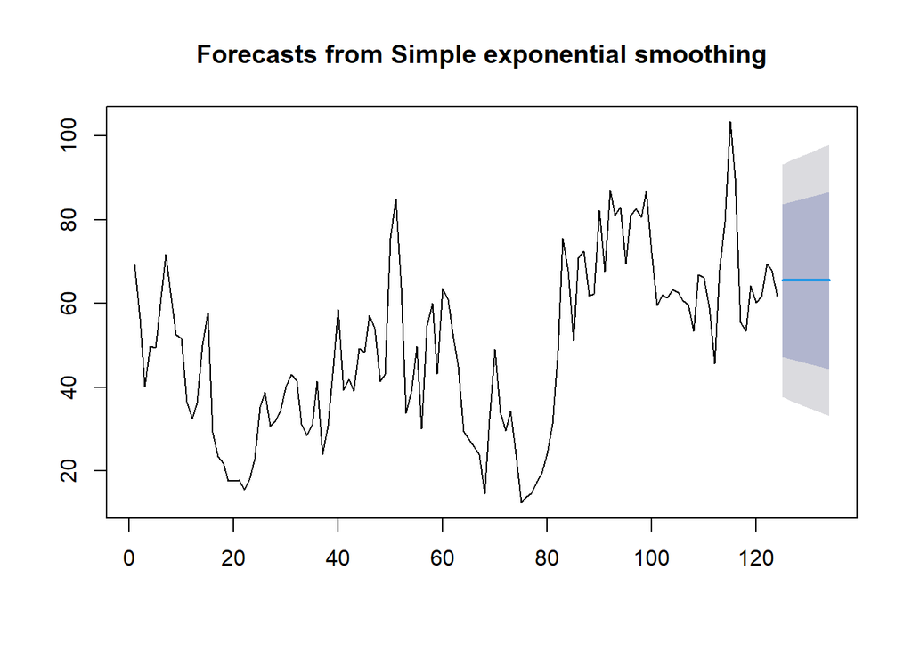

```r
#Cara 1 (fungsi ses)
ses.1 <- ses(train.ts, h = 10, alpha = 0.2)
plot(ses.1)
```

```r
ses.1
```

```
##     Point Forecast    Lo 80    Hi 80    Lo 95    Hi 95
## 125       65.45442 47.31205 83.59680 37.70806 93.20079
## 126       65.45442 46.95276 83.95609 37.15857 93.75027
## 127       65.45442 46.60032 84.30853 36.61956 94.28929
## 128       65.45442 46.25434 84.65451 36.09043 94.81841
## 129       65.45442 45.91449 84.99436 35.57068 95.33817
## 130       65.45442 45.58045 85.32840 35.05980 95.84904
## 131       65.45442 45.25193 85.65691 34.55738 96.35147
## 132       65.45442 44.92867 85.98017 34.06300 96.84585
## 133       65.45442 44.61043 86.29842 33.57628 97.33257
## 134       65.45442 44.29696 86.61188 33.09688 97.81197
```

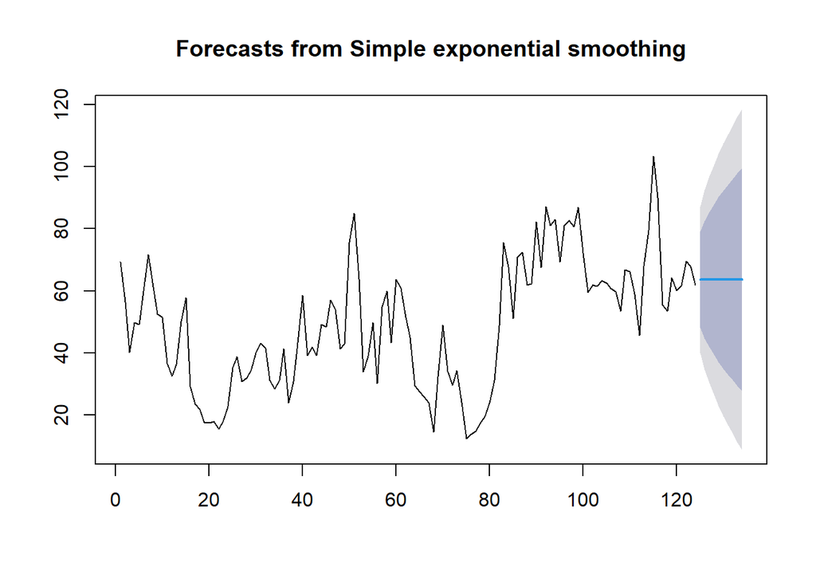

```r
ses.2<- ses(train.ts, h = 10, alpha = 0.7)
plot(ses.2)
```

```r
ses.2
```

```
##     Point Forecast    Lo 80    Hi 80     Lo 95     Hi 95
## 125       63.57517 48.13140 79.01894 39.955959  87.19438
## 126       63.57517 44.72364 82.42670 34.744248  92.40609
## 127       63.57517 41.84386 85.30649 30.339993  96.81035
## 128       63.57517 39.30338 87.84697 26.454665 100.69568
## 129       63.57517 37.00470 90.14564 22.939142 104.21120
## 130       63.57517 34.88964 92.26071 19.704431 107.44591
## 131       63.57517 32.92016 94.23019 16.692373 110.45797
## 132       63.57517 31.06979 96.08055 13.862480 113.28786
## 133       63.57517 29.31923 97.83112 11.185224 115.96512
## 134       63.57517 27.65387 99.49647  8.638285 118.51206
```

Pada fungsi `ses()` , terdapat beberapa argumen yang umum digunakan, yaitu

- `y` : nilai data deret waktu
- `alpha` : parameter pemulusan utama (0–1), mengatur bobot data terbaru vs data lama.
- `beta` : parameter pemulusan tren.
- `gamma` : parameter pemulusan musiman.
- `h` : jumlah periode ke depan yang ingin diramalkan (forecast horizon).

  Kasus di atas merupakan contoh inisialisasi nilai parameter $\lambda$ dengan nilai `alpha` 0,2 dan 0,7 dan banyak periode data yang akan diramalkan adalah sebanyak 10 periode.

Untuk mendapatkan gambar hasil pemulusan pada data latih dengan fungsi `ses()` , perlu digunakan fungsi `autoplot()` dan `autolayer()` dari *library packages* `ggplot2` .

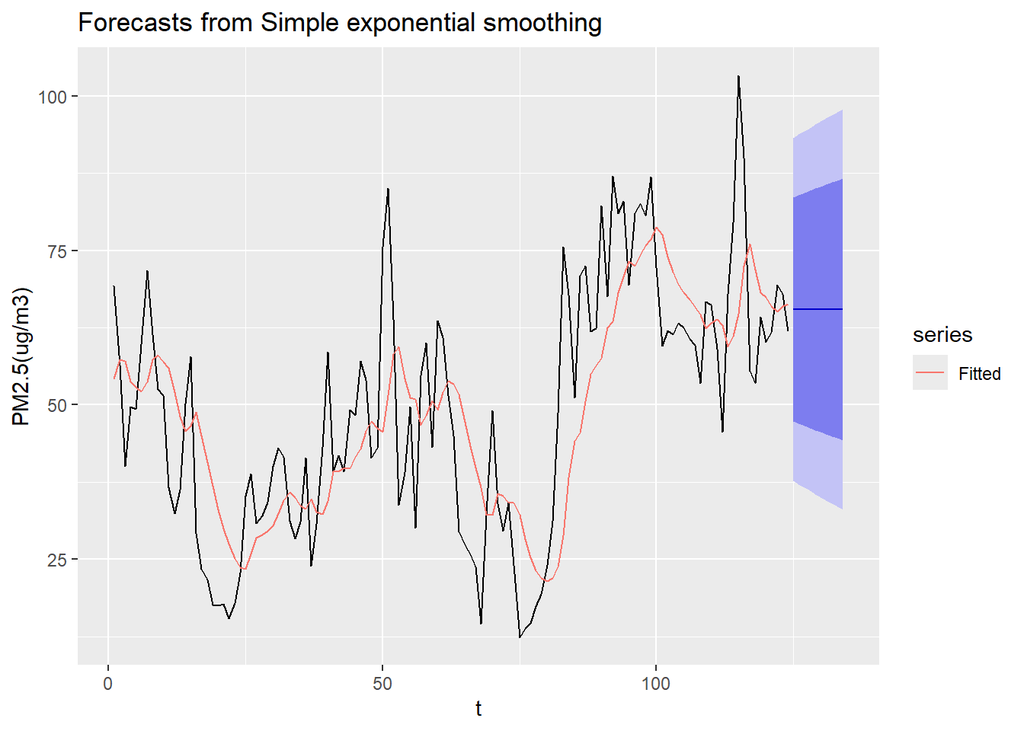

```r
autoplot(ses.1) +
  autolayer(fitted(ses.1), series="Fitted") +
  ylab("PM2.5(ug/m3)") + xlab("t")
```

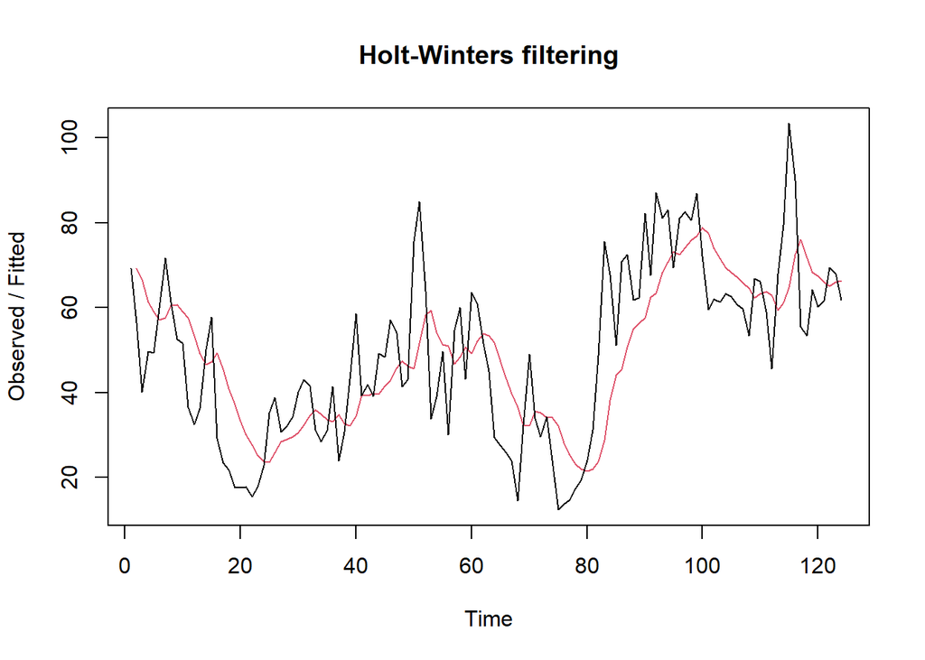

```r
#Cara 2 (fungsi Holtwinter)
ses1<- HoltWinters(train.ts, gamma = FALSE, beta = FALSE, alpha = 0.2)
plot(ses1)
```

```r
#ramalan
ramalan1<- forecast(ses1, h=32)
ramalan1
```

```
##     Point Forecast    Lo 80    Hi 80    Lo 95     Hi 95
## 125       65.45442 47.08282 83.82603 37.35748  93.55136
## 126       65.45442 46.71899 84.18985 36.80105  94.10779
## 127       65.45442 46.36210 84.54675 36.25523  94.65362
## 128       65.45442 46.01175 84.89710 35.71942  95.18943
## 129       65.45442 45.66760 85.24124 35.19309  95.71575
## 130       65.45442 45.32934 85.57950 34.67577  96.23308
## 131       65.45442 44.99667 85.91217 34.16700  96.74185
## 132       65.45442 44.66933 86.23952 33.66636  97.24248
## 133       65.45442 44.34706 86.56179 33.17350  97.73535
## 134       65.45442 44.02964 86.87921 32.68804  98.22080
## 135       65.45442 43.71685 87.19200 32.20968  98.69917
## 136       65.45442 43.40850 87.50035 31.73810  99.17075
## 137       65.45442 43.10441 87.80444 31.27302  99.63583
## 138       65.45442 42.80439 88.10446 30.81419 100.09466
```

[output cut: 18 more lines]

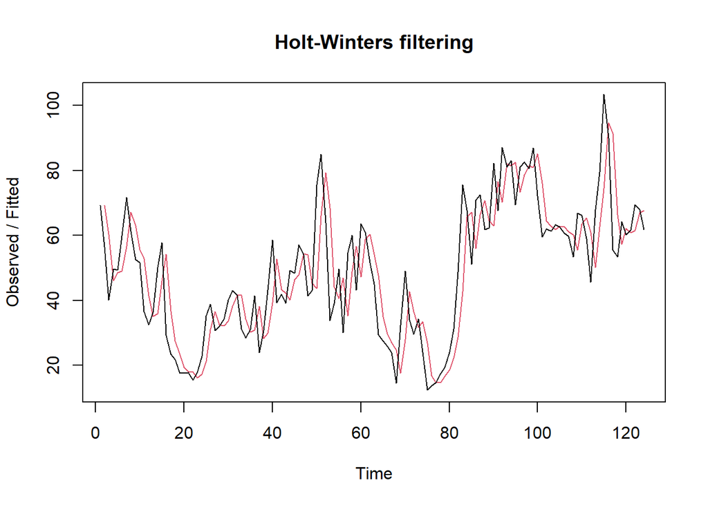

```r
ses2<- HoltWinters(train.ts, gamma = FALSE, beta = FALSE, alpha = 0.7)
plot(ses2)
```

```r
#ramalan
ramalan2<- forecast(ses2, h=32)
ramalan2
```

```
##     Point Forecast     Lo 80     Hi 80       Lo 95     Hi 95
## 125       63.57517 48.119469  79.03087  39.9377145  87.21263
## 126       63.57517 44.709082  82.44126  34.7219782  92.42836
## 127       63.57517 41.827070  85.32327  30.3143213  96.83602
## 128       63.57517 39.284628  87.86571  26.4259918 100.72435
## 129       63.57517 36.984176  90.16617  22.9077528 104.24259
## 130       63.57517 34.867478  92.28286  19.6705438 107.47980
## 131       63.57517 32.896478  94.25386  16.6561591 110.49418
## 132       63.57517 31.044681  96.10566  13.8240799 113.32626
## 133       63.57517 29.292765  97.85758  11.1447557 116.00559
## 134       63.57517 27.626125  99.52422   8.5958491 118.55449
## 135       63.57517 26.033401 101.11694   6.1599881 120.99035
## 136       63.57517 24.505553 102.64479   3.8233458 123.32700
## 137       63.57517 23.035244 104.11510   1.5747032 125.57564
## 138       63.57517 21.616427 105.53392  -0.5951913 127.74553
```

[output cut: 18 more lines]

Fungsi `HoltWinters` memiliki argumen yang sama dengan fungsi `ses()` . Argumen-argumen kedua fungsi dapat dilihat lebih lanjut dengan `?ses()` atau `?HoltWinters` .

Nilai parameter $\alpha$ dari kedua fungsi dapat dioptimalkan menyesuaikan dari *error*-nya paling minimumnya. Caranya adalah dengan membuat parameter $\alpha =$ `NULL` .

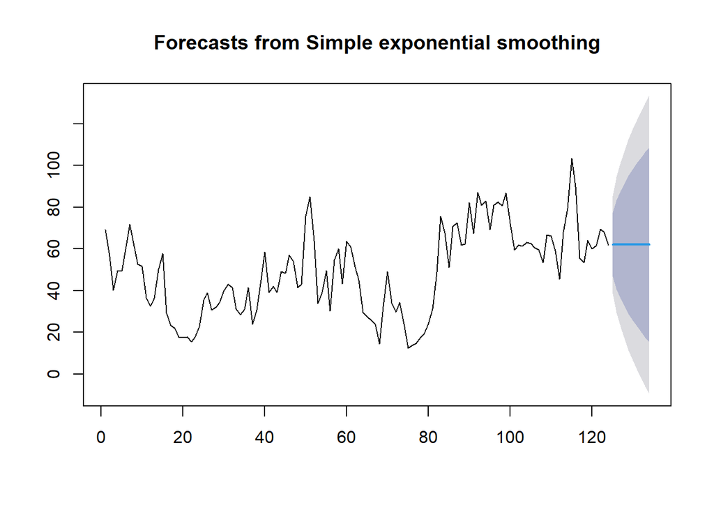

```r
#SES
ses.opt <- ses(train.ts, h = 10, alpha = NULL)
plot(ses.opt)
```

```r
ses.opt
```

```
##     Point Forecast    Lo 80     Hi 80     Lo 95     Hi 95
## 125       62.02838 46.78013  77.27664 38.708197  85.34857
## 126       62.02838 40.81146  83.24531 29.579896  94.47687
## 127       62.02838 36.18643  87.87034 22.506522 101.55025
## 128       62.02838 32.27178  91.78499 16.519585 107.53719
## 129       62.02838 28.81537  95.24140 11.233462 112.82331
## 130       62.02838 25.68622  98.37055  6.447836 117.60893
## 131       62.02838 22.80592 101.25085  2.042798 122.01397
## 132       62.02838 20.12313 103.93364 -2.060178 126.11695
## 133       62.02838 17.60205 106.45472 -5.915836 129.97261
## 134       62.02838 15.21655 108.84022 -9.564145 133.62091
```

```r
#Lamda Optimum Holt Winter
HWopt<- HoltWinters(train.ts, gamma = FALSE, beta = FALSE,alpha = NULL)
HWopt
```

```
## Holt-Winters exponential smoothing without trend and without seasonal component.
##
## Call:
## HoltWinters(x = train.ts, alpha = NULL, beta = FALSE, gamma = FALSE)
##
## Smoothing parameters:
##  alpha: 0.9683286
##  beta : FALSE
##  gamma: FALSE
##
## Coefficients:
##       [,1]
## a 62.02338
```

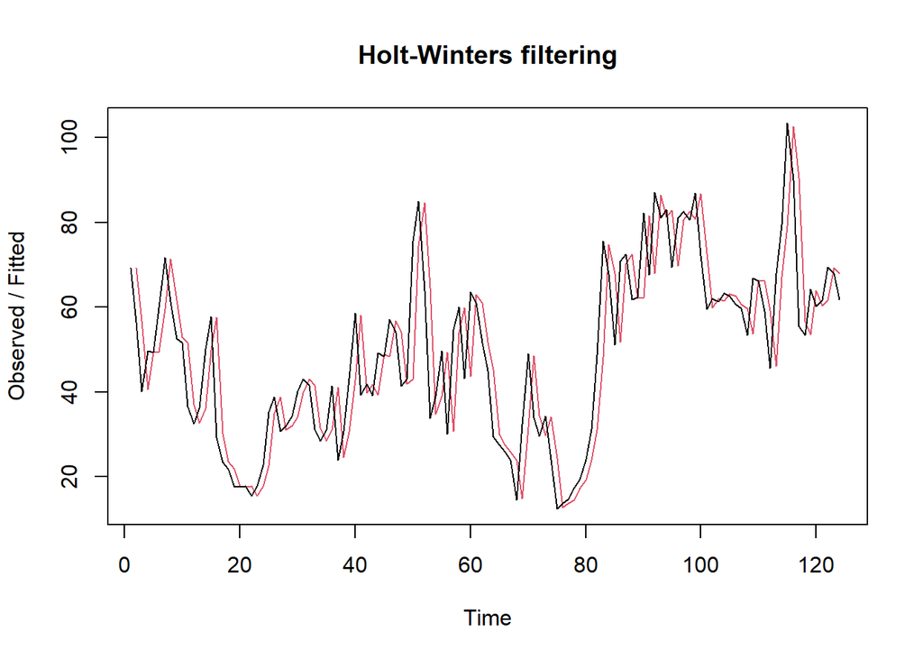

```r
plot(HWopt)
```

```r
#ramalan
ramalanopt<- forecast(HWopt, h=32)
ramalanopt
```

```
##     Point Forecast       Lo 80     Hi 80      Lo 95     Hi 95
## 125       62.02338  46.7752444  77.27151  38.703371  85.34338
## 126       62.02338  40.7979976  83.24875  29.561961  94.48479
## 127       62.02338  36.1674704  87.87928  22.480181 101.56657
## 128       62.02338  32.2485708  91.79818  16.486741 107.56001
## 129       62.02338  28.7886021  95.25815  11.195175 112.85158
## 130       62.02338  25.6563392  98.39041   6.404793 117.64196
## 131       62.02338  22.7732481 101.27350   1.995486 122.05127
## 132       62.02338  20.0879052 103.95885  -2.111392 126.15814
## 133       62.02338  17.5644637 106.48229  -5.970663 130.01741
## 134       62.02338  15.1767534 108.87000  -9.622351 133.66910
## 135       62.02338  12.9049760 111.14178 -13.096734 137.14349
## 136       62.02338  10.7337241 113.31303 -16.417378 140.46413
## 137       62.02338   8.6507279 115.39602 -19.603045 143.64980
## 138       62.02338   6.6460275 117.40072 -22.668970 146.71572
```

[output cut: 18 more lines]

Setelah dilakukan peramalan, akan dilakukan perhitungan keakuratan hasil peramalan. Perhitungan akurasi ini dilakukan baik pada data latih dan data uji.

#### Akurasi Data Latih

Perhitungan akurasi data dapat dilakukan dengan cara langsung maupun manual. Secara langsung, nilai akurasi dapat diambil dari objek yang tersimpan pada hasil SES, yaitu *sum of squared errors* (SSE). Nilai akurasi lain dapat dihitung pula dari nilai SSE tersebut.

```r
#Keakuratan Metode
#Pada data training

# SES dengan alpha = 0.2
SSE1<-ses1$SSE
MSE1<-ses1$SSE/length(train.ts)
RMSE1<-sqrt(MSE1)

akurasi1 <- matrix(c(SSE1,MSE1,RMSE1))
row.names(akurasi1)<- c("SSE", "MSE", "RMSE")
colnames(akurasi1) <- c("Akurasi lamda=0.2")
akurasi1
```

```
##      Akurasi lamda=0.2
## SSE         25074.5398
## MSE           202.2140
## RMSE           14.2202
```

```r
# SES dengan alpha = 0.7
SSE2<-ses2$SSE
MSE2<-ses2$SSE/length(train.ts)
RMSE2<-sqrt(MSE2)

akurasi2 <- matrix(c(SSE2,MSE2,RMSE2))
row.names(akurasi2)<- c("SSE", "MSE", "RMSE")
colnames(akurasi2) <- c("Akurasi lamda=0.7")
akurasi2
```

```
##      Akurasi lamda=0.7
## SSE        17745.09468
## MSE          143.10560
## RMSE          11.96268
```

```r
#Cara Manual
# Alpha = 0.2
fitted1<-ramalan1$fitted
sisaan1<-ramalan1$residuals
head(sisaan1)
```

```
## Time Series:
## Start = 1
## End = 6
## Frequency = 1
## [1]         NA -12.854100 -26.633280 -11.710824  -9.772859   2.748413
```

```r
resid1<-training$"PM2.5(ug/m3)"-ramalan1$fitted
head(resid1)
```

```
## Time Series:
## Start = 1
## End = 6
## Frequency = 1
## [1]         NA -12.854100 -26.633280 -11.710824  -9.772859   2.748413
```

```r
SSE.1=sum(sisaan1[2:length(train.ts)]^2)
SSE.1
```

```
## [1] 25074.54
```

```r
MSE.1 = SSE.1/length(train.ts)
MSE.1
```

```
## [1] 202.214
```

```r
MAPE.1 = sum(abs(sisaan1[2:length(train.ts)]/train.ts[2:length(train.ts)])*
               100)/length(train.ts)
MAPE.1
```

```
## [1] 29.05254
```

```r
akurasi.1 <- matrix(c(SSE.1,MSE.1,MAPE.1))
row.names(akurasi.1)<- c("SSE", "MSE", "MAPE")
colnames(akurasi.1) <- c("Akurasi lamda=0.2")
akurasi.1
```

```
##      Akurasi lamda=0.2
## SSE        25074.53976
## MSE          202.21403
## MAPE          29.05254
```

```r
# Alpha = 0.7
fitted2<-ramalan2$fitted
sisaan2<-ramalan2$residuals
head(sisaan2)
```

```
## Time Series:
## Start = 1
## End = 6
## Frequency = 1
## [1]          NA -12.8541000 -20.2062300   3.5339310   0.6559793  10.7634938
```

```r
resid2<-training$"PM2.5(ug/m3)"-ramalan2$fitted
head(resid2)
```

```
## Time Series:
## Start = 1
## End = 6
## Frequency = 1
## [1]          NA -12.8541000 -20.2062300   3.5339310   0.6559793  10.7634938
```

```r
SSE.2=sum(sisaan2[2:length(train.ts)]^2)
SSE.2
```

```
## [1] 17745.09
```

```r
MSE.2 = SSE.2/length(train.ts)
MSE.2
```

```
## [1] 143.1056
```

```r
MAPE.2 = sum(abs(sisaan2[2:length(train.ts)]/train.ts[2:length(train.ts)])*
               100)/length(train.ts)
MAPE.2
```

```
## [1] 21.18072
```

```r
akurasi.2 <- matrix(c(SSE.2,MSE.2,MAPE.2))
row.names(akurasi.2)<- c("SSE", "MSE", "MAPE")
colnames(akurasi.2) <- c("Akurasi lamda=0.7")
akurasi.2
```

```
##      Akurasi lamda=0.7
## SSE        17745.09468
## MSE          143.10560
## MAPE          21.18072
```

Berdasarkan nilai SSE, MSE, RMSE, dan MAPE di antara kedua parameter, nilai parameter $\lambda=0,7$ menghasilkan akurasi yang lebih baik dibanding $\lambda=0,2$ . Hal ini dilihat dari nilai masing-masing ukuran akurasi yang lebih kecil. Berdasarkan nilai MAPE-nya, hasil ini dapat dikategorikan sebagai peramalan ,mid.

#### Akurasi Data Uji

Akurasi data uji dapat dihitung dengan cara yang hampir sama dengan perhitungan akurasi data latih.

```r
# jumlah observasi uji
n_test <- nrow(testing)

# error (ramalan - aktual), samakan panjang dan tipe numeric
e1   <- as.numeric(ramalan1$mean)[1:n_test] - as.numeric(testing$"PM2.5(ug/m3)")
e2   <- as.numeric(ramalan2$mean)[1:n_test] - as.numeric(testing$"PM2.5(ug/m3)")
eopt <- as.numeric(ramalanopt$mean)[1:n_test] - as.numeric(testing$"PM2.5(ug/m3)")

# SSE / MSE / RMSE untuk masing-masing model (abaikan NA)
SSEtesting1  <- sum(e1^2,  na.rm = TRUE)
MSEtesting1  <- mean(e1^2, na.rm = TRUE)
RMSEtesting1 <- sqrt(MSEtesting1)

SSEtesting2  <- sum(e2^2,  na.rm = TRUE)
MSEtesting2  <- mean(e2^2, na.rm = TRUE)
RMSEtesting2 <- sqrt(MSEtesting2)

SSEtestingopt  <- sum(eopt^2,  na.rm = TRUE)
MSEtestingopt  <- mean(eopt^2, na.rm = TRUE)
RMSEtestingopt <- sqrt(MSEtestingopt)

# Tabel ringkas
akurasitesting_SSE <- matrix(c(SSEtesting1, SSEtesting2, SSEtestingopt),
                             nrow = 3,
                             dimnames = list(c("SSE1","SSE2","SSEopt"), "Nilai"))
akurasitesting_MSE <- matrix(c(MSEtesting1, MSEtesting2, MSEtestingopt),
                             nrow = 3,
                             dimnames = list(c("MSE1","MSE2","MSEopt"), "Nilai"))
akurasitesting_RMSE <- matrix(c(RMSEtesting1, RMSEtesting2, RMSEtestingopt),
                              nrow = 3,
                              dimnames = list(c("RMSE1","RMSE2","RMSEopt"), "Nilai"))

akurasitesting_SSE
```

```
##           Nilai
## SSE1   22609.16
## SSE2   25179.20
## SSEopt 27471.79
```

```r
akurasitesting_MSE
```

```
##           Nilai
## MSE1   706.5363
## MSE2   786.8501
## MSEopt 858.4935
```

```r
akurasitesting_RMSE
```

```
##            Nilai
## RMSE1   26.58075
## RMSE2   28.05085
## RMSEopt 29.30006
```

Selain dengan cara di atas, perhitungan nilai akurasi dapat menggunakan fungsi `accuracy()` dari *package* `forecast` . Penggunaannya yaitu dengan menuliskan `accuracy(hasil ramalan, kondisi aktual)` . Contohnya adalah sebagai berikut.

```r
library(forecast)
accuracy(ramalan1, testing$"PM2.5(ug/m3)")
```

```
##                      ME     RMSE      MAE       MPE     MAPE     MASE     ACF1
## Training set -0.1551373 14.27789 11.44321 -11.12576 29.28874 1.266567 0.594056
## Test set     20.4289076 26.58075 22.14484  20.49219 23.65820 2.451053       NA
```

```r
accuracy(ramalan2, testing$"PM2.5(ug/m3)")
```

```
##                       ME     RMSE       MAE       MPE     MAPE     MASE
## Training set -0.06615132 12.01121  9.189942 -4.834469 21.35292 1.017169
## Test set     22.30815990 28.05085 23.671730 22.774928 25.31171 2.620054
##                  ACF1
## Training set 0.193595
## Test set           NA
```

```r
accuracy(ramalanopt, testing$"PM2.5(ug/m3)")
```

```
##                       ME     RMSE      MAE       MPE     MAPE     MASE
## Training set -0.06084933 11.84987  9.02421 -3.648698 20.42301 0.998825
## Test set     23.85995522 29.30006 24.93256 24.659901 26.67710 2.759606
##                     ACF1
## Training set 0.009649901
## Test set              NA
```

## *Double Exponential Smoothing* (DES)

Metode pemulusan *Double Exponential Smoothing* (DES) digunakan untuk data yang memiliki pola tren. Metode DES adalah metode semacam SES, hanya saja dilakukan dua kali, yaitu pertama untuk tahapan ‘level’ dan kedua untuk tahapan ‘tren’. Pemulusan menggunakan metode ini akan menghasilkan peramalan tidak konstan untuk periode berikutnya.

Pemulusan dengan metode DES kali ini akan menggunakan fungsi `HoltWinters()` . Jika sebelumnya nilai argumen `beta` dibuat `FALSE` , kali ini argumen tersebut akan diinisialisasi bersamaan dengan nilai `alpha` .

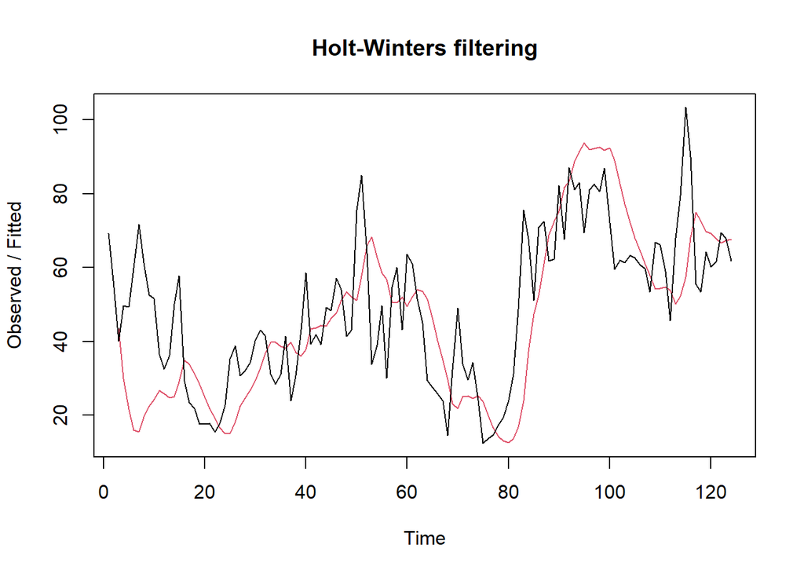

```r
#Lamda=0.2 dan gamma=0.2
des.1<- HoltWinters(train.ts, gamma = FALSE, beta = 0.2, alpha = 0.2)
plot(des.1)
```

```r
#ramalan
ramalandes1<- forecast(des.1, h=32)
ramalandes1
```

```
##     Point Forecast      Lo 80     Hi 80       Lo 95    Hi 95
## 125       66.41483  44.654951  88.17471   33.135966  99.6937
## 126       66.36716  43.989365  88.74495   32.143278 100.5910
## 127       66.31948  43.127083  89.51188   30.849769 101.7892
## 128       66.27181  42.056667  90.48695   29.237947 103.3057
## 129       66.22413  40.773442  91.67482   27.300661 105.1476
## 130       66.17646  39.278569  93.07434   25.039688 107.3132
## 131       66.12878  37.577696  94.67987   22.463665 109.7939
## 132       66.08111  35.679510  96.48270   19.585876 112.5763
## 133       66.03343  33.594421  98.47244   16.422245 115.6446
## 134       65.98576  31.333533 100.63798   12.989753 118.9818
## 135       65.93808  28.907907 102.96826    9.305316 122.5708
## 136       65.89041  26.328097 105.45272    5.385075 126.3957
## 137       65.84273  23.603897 108.08157    1.244008 130.4415
## 138       65.79506  20.744223 110.84589   -3.104248 134.6944
```

[output cut: 18 more lines]

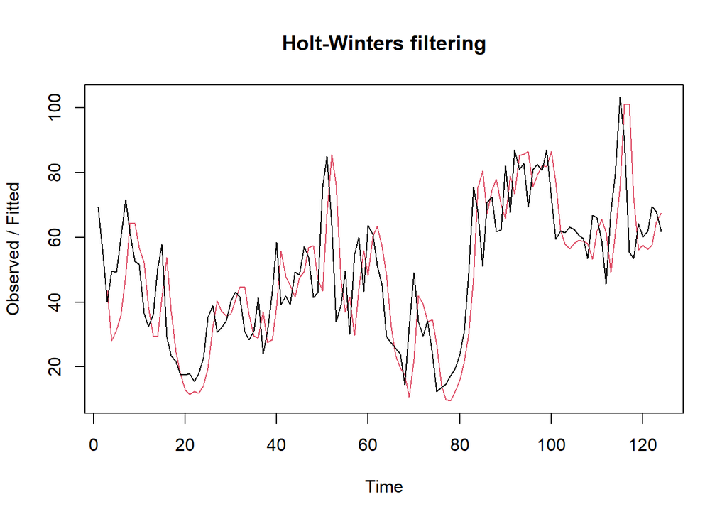

```r
#Lamda=0.6 dan gamma=0.3
des.2<- HoltWinters(train.ts, gamma = FALSE, beta = 0.3, alpha = 0.6)
plot(des.2)
```

```r
#ramalan
ramalandes2<- forecast(des.2, h=32)
ramalandes2
```

```
##     Point Forecast       Lo 80     Hi 80       Lo 95     Hi 95
## 125       63.80052   46.073284  81.52776   36.689053  90.91199
## 126       63.52974   41.047577  86.01190   29.146240  97.91324
## 127       63.25896   35.062062  91.45585   20.135527 106.38239
## 128       62.98817   28.297102  97.67925    9.932757 116.04359
## 129       62.71739   20.872103 104.56268   -1.279455 126.71424
## 130       62.44661   12.867364 112.02586  -13.378304 138.27153
## 131       62.17583    4.339381 120.01228  -26.277386 150.62904
## 132       61.90505   -4.670106 128.48020  -39.912863 163.72296
## 133       61.63427  -14.128880 137.39741  -54.235466 177.50400
## 134       61.36348  -24.011149 146.73812  -69.205750 191.93272
## 135       61.09270  -34.295642 156.48105  -84.791181 206.97658
## 136       60.82192  -44.964385 166.60823 -100.964273 222.60811
## 137       60.55114  -56.001899 177.10418 -117.701350 238.80363
## 138       60.28036  -67.394638 187.95535 -134.981697 255.54241
```

[output cut: 18 more lines]

Selanjutnya jika ingin membandingkan plot data latih dan data uji adalah sebagai berikut.

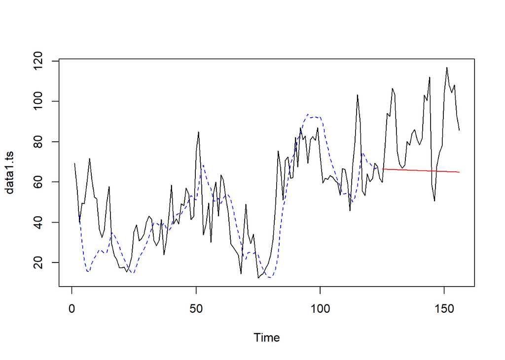

```r
plot(data1.ts)
lines(des.1$fitted[,1], lty=2, col="blue")
lines(ramalandes1$mean, col="red")
```

Untuk mendapatkan nilai parameter optimum dari DES, argumen `alpha` dan `beta` dapat dibuat `NULL` seperti berikut.

```r
#Lamda dan gamma optimum
des.opt<- HoltWinters(train.ts, gamma = FALSE)
des.opt
```

```
## Holt-Winters exponential smoothing with trend and without seasonal component.
##
## Call:
## HoltWinters(x = train.ts, gamma = FALSE)
##
## Smoothing parameters:
##  alpha: 1
##  beta : 0.0723025
##  gamma: FALSE
##
## Coefficients:
##         [,1]
## a 61.8292000
## b -0.2806053
```

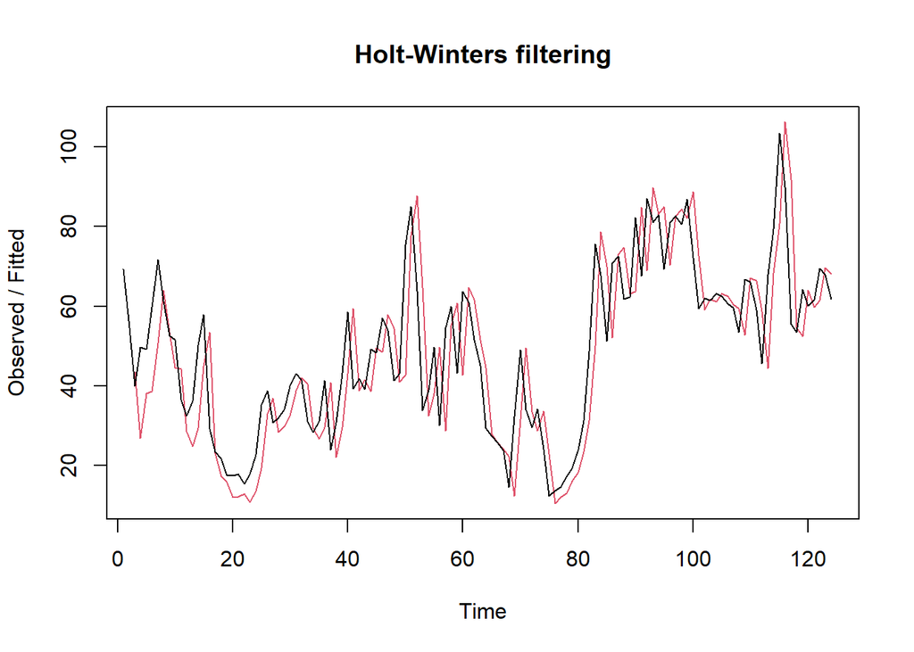

```r
plot(des.opt)
```

```r
#ramalan
ramalandesopt<- forecast(des.opt, h=32)
ramalandesopt
```

```
##     Point Forecast       Lo 80     Hi 80       Lo 95     Hi 95
## 125       61.54859   45.487829  77.60936   36.985773  86.11142
## 126       61.26799   37.719201  84.81678   25.253225  97.28275
## 127       60.98738   31.112835  90.86193   15.298204 106.67656
## 128       60.70678   25.006991  96.40657    6.108665 115.30489
## 129       60.42617   19.156319 101.69603   -2.690622 123.54297
## 130       60.14557   13.440498 106.85064  -11.283673 131.57481
## 131       59.86496    7.791360 111.93857  -19.774740 139.50467
## 132       59.58436    2.166702 117.00201  -28.228369 147.39708
## 133       59.30375   -3.461220 122.06873  -36.686990 155.29449
## 134       59.02315   -9.111432 127.15773  -45.179700 163.22599
## 135       58.74254  -14.797389 132.28247  -53.727077 171.21216
## 136       58.46194  -20.528824 137.45270  -62.344007 179.26788
## 137       58.18133  -26.312895 142.67556  -71.041437 187.40410
## 138       57.90073  -32.154927 147.95638  -79.827510 195.62896
```

[output cut: 18 more lines]

Selanjutnya akan dilakukan perhitungan akurasi pada data latih maupun data uji dengan ukuran akurasi SSE, MSE dan MAPE.

#### Akurasi Data Latih

```r
#Akurasi Data Training
ssedes.train1<-des.1$SSE
msedes.train1<-ssedes.train1/length(train.ts)
sisaandes1<-ramalandes1$residuals
head(sisaandes1)
```

```
## Time Series:
## Start = 1
## End = 6
## Frequency = 1
## [1]       NA       NA -3.49590 19.79302 27.63243 43.76956
```

```r
mapedes.train1 <- sum(abs(sisaandes1[3:length(train.ts)]/train.ts[3:length(train.ts)])
                      *100)/length(train.ts)

akurasides.1 <- matrix(c(ssedes.train1,msedes.train1,mapedes.train1))
row.names(akurasides.1)<- c("SSE", "MSE", "MAPE")
colnames(akurasides.1) <- c("Akurasi lamda=0.2 dan gamma=0.2")
akurasides.1
```

```
##      Akurasi lamda=0.2 dan gamma=0.2
## SSE                       35724.1801
## MSE                         288.0982
## MAPE                         29.3298
```

```r
ssedes.train2<-des.2$SSE
msedes.train2<-ssedes.train2/length(train.ts)
sisaandes2<-ramalandes2$residuals
head(sisaandes2)
```

```
## Time Series:
## Start = 1
## End = 6
## Frequency = 1
## [1]       NA       NA -3.49590 21.68080 17.84894 24.07428
```

```r
mapedes.train2 <- sum(abs(sisaandes2[3:length(train.ts)]/train.ts[3:length(train.ts)])
                      *100)/length(train.ts)

akurasides.2 <- matrix(c(ssedes.train2,msedes.train2,mapedes.train2))
row.names(akurasides.2)<- c("SSE", "MSE", "MAPE")
colnames(akurasides.2) <- c("Akurasi lamda=0.6 dan gamma=0.3")
akurasides.2
```

```
##      Akurasi lamda=0.6 dan gamma=0.3
## SSE                      23192.41654
## MSE                        187.03562
## MAPE                        24.52894
```

#### Akurasi Data Uji

```r
#Akurasi Data Testing
selisihdes1<-ramalandes1$mean-testing$"PM2.5(ug/m3)"
selisihdes1
```

```
## Time Series:
## Start = 125
## End = 156
## Frequency = 1
##  [1]   6.6273307 -10.4703441 -27.7597190 -26.2864938 -40.2425686 -37.4652434
##  [7]  -8.9587182  -2.9188931  -0.8290679  -2.4434427 -14.2702175 -12.3803923
## [13] -18.1572672 -20.3299420 -15.3068168 -12.8377916 -15.9229664 -37.6039413
## [19] -34.8766161 -46.5242909   6.9821343  14.7719595  -2.5548154  -9.2816902
## [25] -12.5960650 -39.0603398 -51.7039146 -42.8806895 -39.1867643 -43.2385391
## [31] -28.1237139 -20.8088887
```

```r
SSEtestingdes1<-sum(selisihdes1^2)
MSEtestingdes1<-SSEtestingdes1/length(testing$"PM2.5(ug/m3)")
MAPEtestingdes1<-sum(abs(selisihdes1/testing$"PM2.5(ug/m3)")*100)/length(testing$"PM2.5(ug/m3)")

selisihdes2<-ramalandes2$mean-testing$"PM2.5(ug/m3)"
selisihdes2
```

```
## Time Series:
## Start = 125
## End = 156
## Frequency = 1
##  [1]   4.01302024 -13.30776161 -30.82024346 -29.57012531 -43.74930715
##  [6] -41.19508900 -12.91167085  -7.09495270  -5.22823455  -7.06571640
## [11] -19.11559824 -17.44888009 -23.44886194 -25.84464379 -21.04462564
## [16] -18.79870748 -22.10698933 -44.01107118 -41.50685303 -53.37763488
## [21]  -0.09431673   7.47240143 -10.07748042 -17.02746227 -20.56494412
## [26] -47.25232597 -60.11900782 -51.51888966 -48.04807151 -52.32295336
## [31] -37.43123521 -30.33951706
```

```r
SSEtestingdes2<-sum(selisihdes2^2)
MSEtestingdes2<-SSEtestingdes2/length(testing$"PM2.5(ug/m3)")
MAPEtestingdes2<-sum(abs(selisihdes2/testing$"PM2.5(ug/m3)")*100)/length(testing$"PM2.5(ug/m3)")

selisihdesopt<-ramalandesopt$mean-testing$"PM2.5(ug/m3)"
selisihdesopt
```

```
## Time Series:
## Start = 125
## End = 156
## Frequency = 1
##  [1]   1.761095 -15.569511 -33.091816 -31.851521 -46.040526 -43.496132
##  [7] -15.222537  -9.415642  -7.558748  -9.406053 -21.465758 -19.808863
## [13] -25.818669 -28.224274 -23.434079 -21.197985 -24.516090 -46.429995
## [19] -43.935600 -55.816206  -2.542711   5.014184 -12.545522 -19.505327
## [25] -23.052632 -49.749837 -62.626343 -54.036048 -50.575053 -54.859759
## [31] -39.977864 -32.895969
```

```r
SSEtestingdesopt<-sum(selisihdesopt^2)
MSEtestingdesopt<-SSEtestingdesopt/length(testing$"PM2.5(ug/m3)")
MAPEtestingdesopt<-sum(abs(selisihdesopt/testing$"PM2.5(ug/m3)")*100)/length(testing$"PM2.5(ug/m3)")

akurasitestingdes <-
  matrix(c(SSEtestingdes1,MSEtestingdes1,MAPEtestingdes1,SSEtestingdes2,MSEtestingdes2,
           MAPEtestingdes2,SSEtestingdesopt,MSEtestingdesopt,MAPEtestingdesopt),
         nrow=3,ncol=3)
row.names(akurasitestingdes)<- c("SSE", "MSE", "MAPE")
colnames(akurasitestingdes) <- c("des ske1","des ske2","des opt")
akurasitestingdes
```

```
##         des ske1    des ske2     des opt
## SSE  22466.35945 32343.86060 36615.87579
## MSE    702.07373  1010.74564  1144.24612
## MAPE    23.45878    28.79047    31.16659
```

#### Perbandingan SES dan DES

```r
MSEfull <-
  matrix(c(MSEtesting1,MSEtesting2,MSEtestingopt,MSEtestingdes1,MSEtestingdes2,
           MSEtestingdesopt),nrow=3,ncol=2)
row.names(MSEfull)<- c("ske 1", "ske 2", "ske opt")
colnames(MSEfull) <- c("ses","des")
MSEfull
```

```
##              ses       des
## ske 1   706.5363  702.0737
## ske 2   786.8501 1010.7456
## ske opt 858.4935 1144.2461
```